# Data visualization with ggplot2

Visualizing data in R with the ggplot2 package

Authors: **Mateusz Kuzak**, **Diana Marek**, **Hedi Peterson**

#### Disclaimer

We will be using the functions in the ggplot2 package. There are basic plotting capabilities in basic R, but ggplot2 adds more powerful plotting capabilities.

### Learning Objectives

> - Visualize some of the [mammals data](https://dx.doi.org/10.6084/m9.figshare.1314459.v5) from Figshare [surveys.csv](https://ndownloader.figshare.com/files/2292172)
> - Understand how to plot these data using R ggplot2 package. For more details on using ggplot2 see [official documentation](http://docs.ggplot2.org/current/).
> - Building step by step complex plots with the ggplot2 package

Load required packages

```r
# plotting package
library(ggplot2)
# modern dataframe manipulations
library(dplyr)
```

Load data directly from figshare.

```r
surveys_raw <- read.csv("https://ndownloader.figshare.com/files/2292172")
```

`surveys.csv` data contains some measurements of the animals caught in plots.

## Data cleaning and preparing for plotting

Let’s look at the summary

```r
summary(surveys_raw)
```

There are few things we need to clean in the dataset.

We saw in summary, there were NA’s in weight and hindfoot_length. Let’s remove rows with missing values in weight and hindfoot_length.

```r
surveys_complete <- surveys_raw %>%
                    filter(!is.na(weight), !is.na(hindfoot_length))
```

There are a lot of species with low counts, let’s remove the species with less than 10 counts.

```r
# count records per species
species_counts <- surveys_complete %>%
                  group_by(species_id) %>%
                  tally

head(species_counts)

# get names of those frequent species
frequent_species <- species_counts %>%
                    filter(n >= 10) %>%
                    select(species_id)

surveys_complete <- surveys_complete %>%
           filter(species_id %in% frequent_species$species_id)
```

Make simple scatter plot of `hindfoot_length` (in millimeters) as a function of `weight` (in grams), using basic R plotting capabilities.

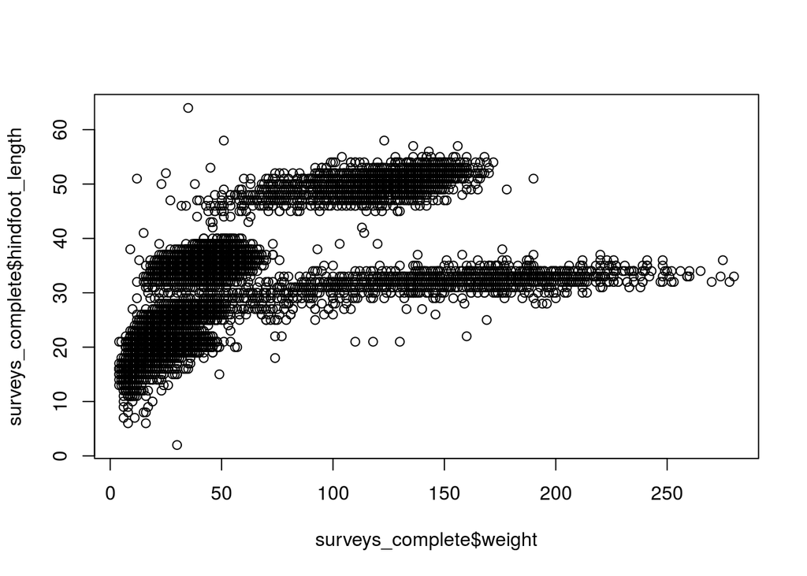

```r
plot(x = surveys_complete$weight, y = surveys_complete$hindfoot_length)
```

## Plotting with ggplot2

We will make the same plot using the `ggplot2` package.

`ggplot2` is a plotting package that makes it simple to create complex plots from data in a dataframe. It uses default settings, which help creating publication quality plots with a minimal amount of settings and tweaking.

`ggplot` graphics are built step by step by adding new elements.

To build a ggplot we need to:

- bind the plot to a specific data frame using the `data` argument

```r
ggplot(data = surveys_complete)
```

- define aesthetics (`aes`), that maps variables in the data to axes on the plot or to plotting size, shape color, etc.,

```r
ggplot(data = surveys_complete, aes(x = weight, y = hindfoot_length))
```

- add `geoms` – graphical representation of the data in the plot (points, lines, bars). To add a geom to the plot use `+` operator:

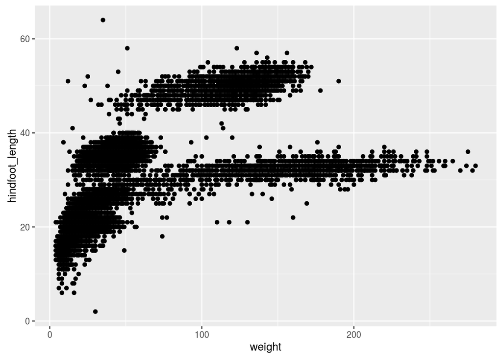

```r
ggplot(data = surveys_complete, aes(x = weight, y = hindfoot_length)) +
  geom_point()
```

Notes:

- Anything you put in the `ggplot()` function can be seen by any geom layers that you add. i.e. these are universal plot settings
- This includes the x and y axis you set up in `aes()`

## Modifying plots

- adding transparency (alpha)

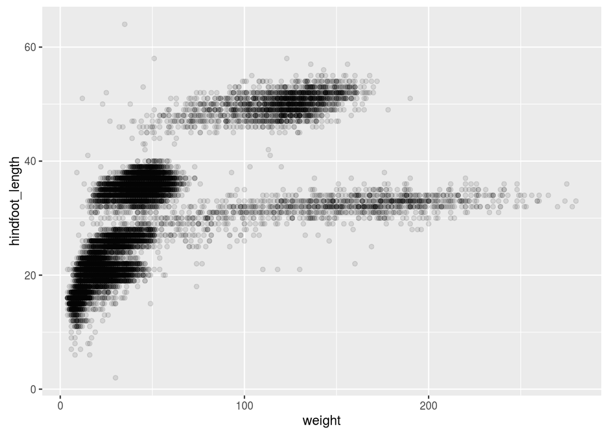

```r
ggplot(data = surveys_complete, aes(x = weight, y = hindfoot_length)) +
  geom_point(alpha = 0.1)
```

- adding colors

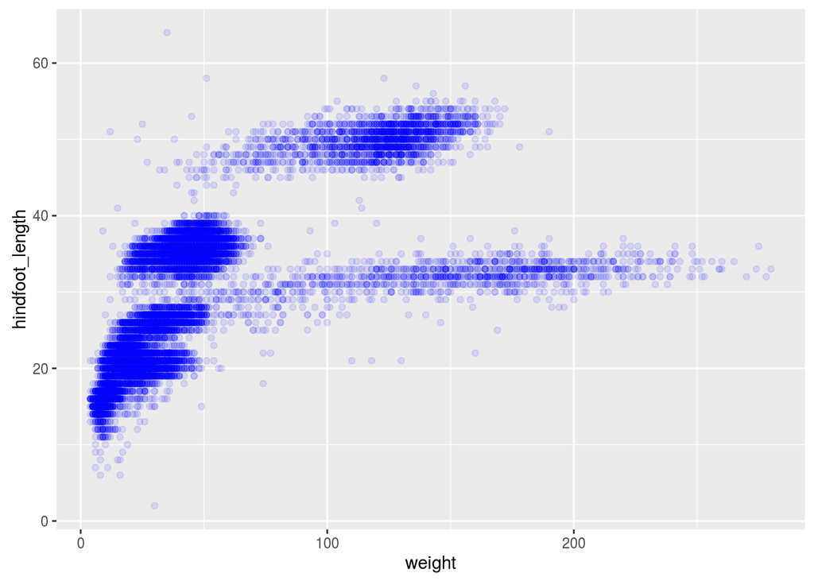

```r
ggplot(data = surveys_complete, aes(x = weight, y = hindfoot_length)) +
  geom_point(alpha = 0.1, color = "blue")
```

## Boxplot

Visualising the distribution of weight within each species.

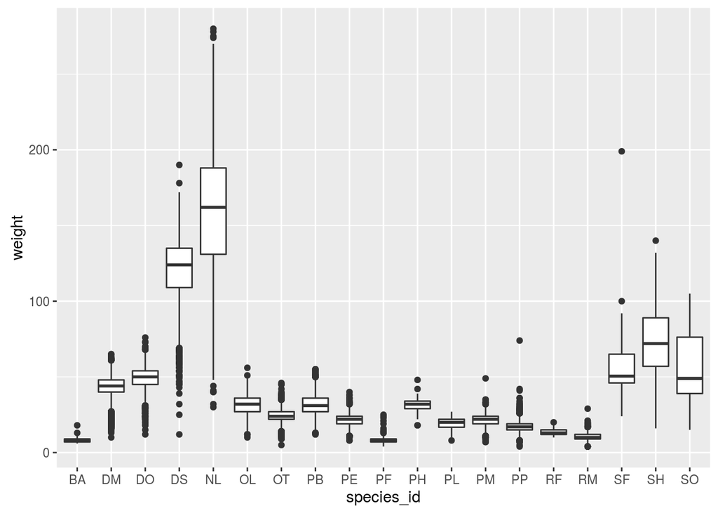

```r
ggplot(data = surveys_complete, aes(x = species_id,  y = weight)) +
                   geom_boxplot()
```

By adding points to boxplot, we can see particular measurements and the abundance of measurements.

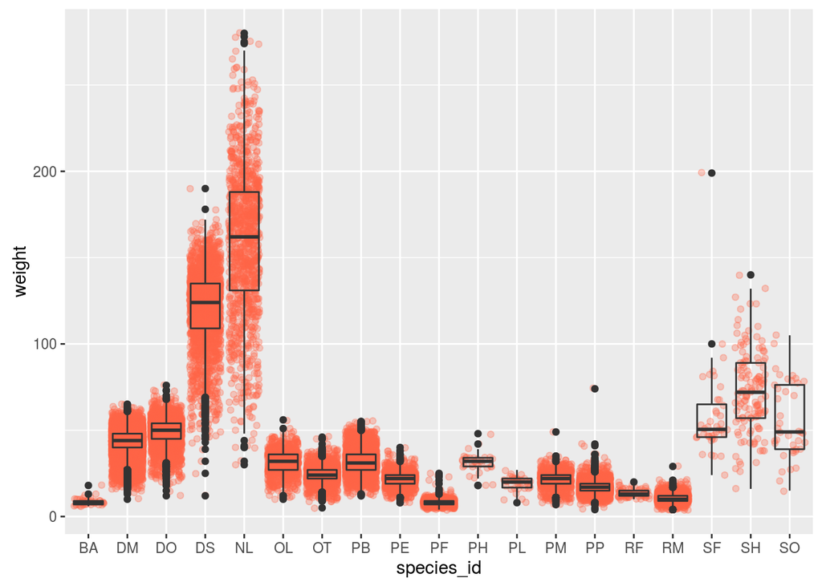

```r
ggplot(data = surveys_complete, aes(x = species_id, y = weight)) +
                   geom_jitter(alpha = 0.3, color = "tomato") +
                   geom_boxplot(alpha = 0)
```

Notice how the boxplot layer is on top of the jitter layer? Play around with the order of geoms and adjust transparency to see how to build up your plot in layers.

### Challenges

Boxplots are useful summaries, but hide the *shape* of the distribution. For example, if there is a bimodal distribution, this would not be observed with a boxplot. An alternative is a violin plot (sometimes known as a beanplot), where the shape (of the density of points) is drawn.

> - Replace the box plot with a violin plot; see `geom_violin()`

In many types of data, it is important to consider the *scale* of the observations. For example, it may be worth changing the scale of the axis to better distribute the observations in the space of the plot. Changing the scale of the axes is done similarly to adding/modifying other components (i.e., by incrementally adding commands).

> - Represent weight on the log10 scale; see `scale_y_log10()`
> - Create boxplot for `hindfoot_length`.

## Plotting time series data

Let’s calculate number of counts per year for each species. To do that we need to group data first and count records within each group.

```r
yearly_counts <- surveys_complete %>%
                 group_by(year, species_id) %>%
                 tally
```

Timelapse data can be visualised as a line plot with years on x axis and counts on y axis.

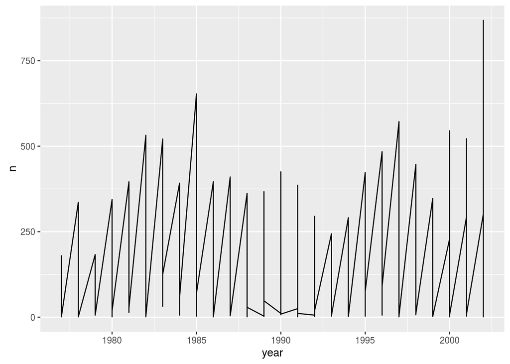

```r
ggplot(data = yearly_counts, aes(x = year, y = n)) +
                  geom_line()
```

Unfortunately this does not work, because we plot data for all the species together. We need to tell ggplot to split graphed data by `species_id`

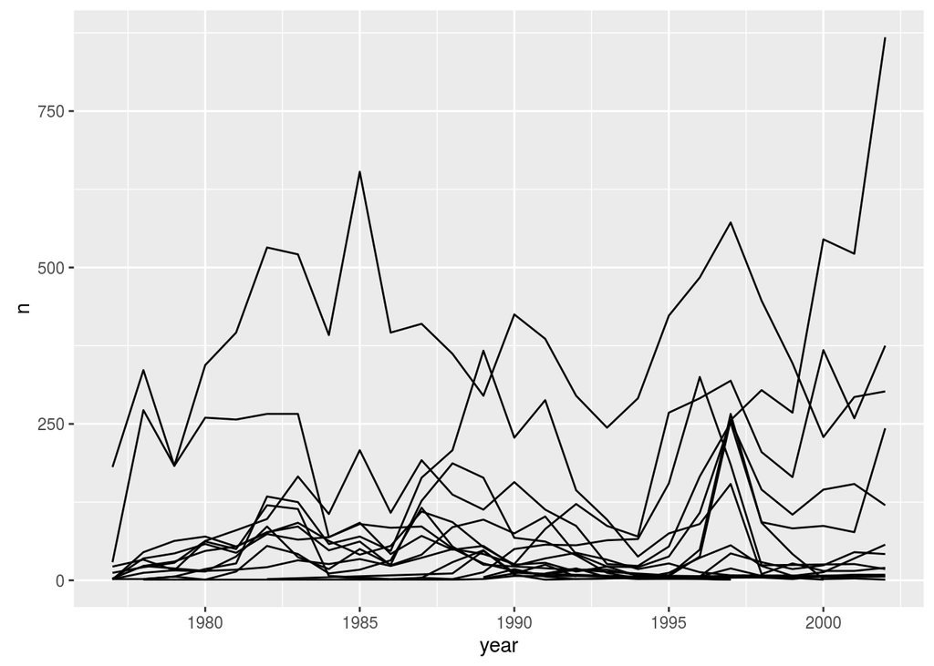

```r
ggplot(data = yearly_counts, aes(x = year, y = n, group = species_id)) +
  geom_line()
```

We will be able to distinguish species in the plot if we add colors.

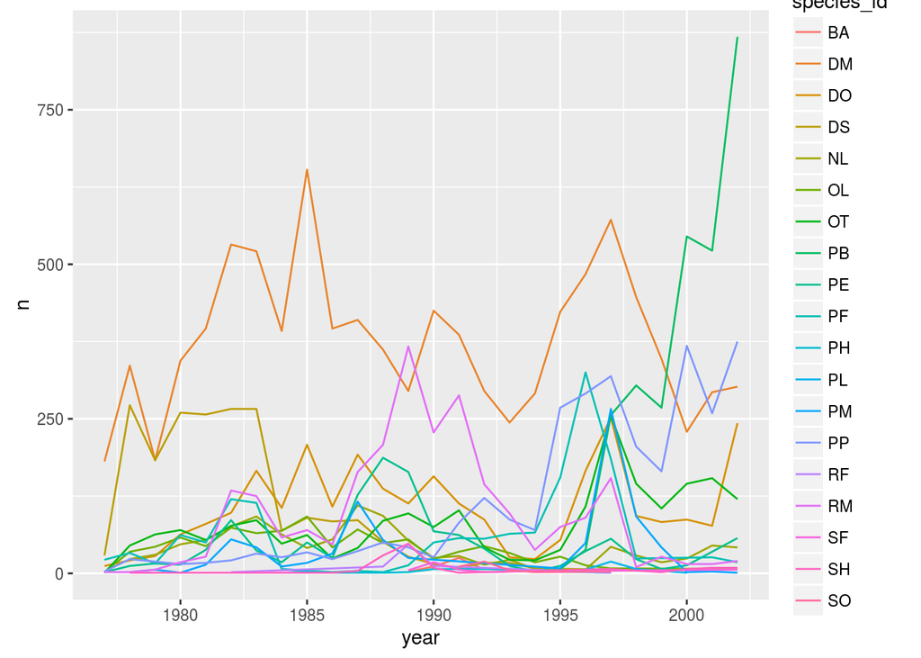

```r
ggplot(data = yearly_counts, aes(x = year, y = n, group = species_id, color = species_id)) +
  geom_line()
```

## Faceting

ggplot has a special technique called *faceting* that allows to split one plot into multiple plots based on some factor. We will use it to plot one time series for each species separately.

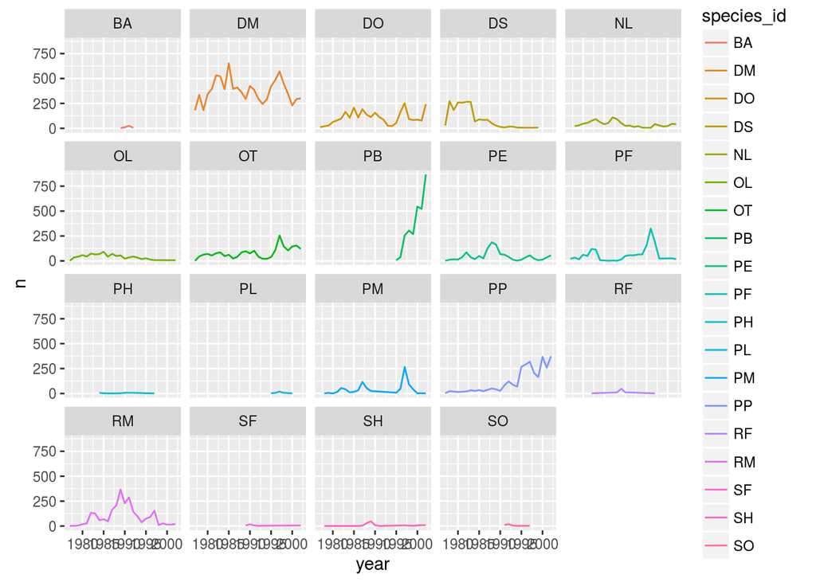

```r
ggplot(data = yearly_counts, aes(x = year, y = n, color = species_id)) +
  geom_line() + facet_wrap(~species_id)
```

Now we would like to split line in each plot by sex of each individual measured. To do that we need to make counts in dataframe grouped by sex.

### Challenges:

> - filter the dataframe so that we only keep records with sex “F” or “M”s

```r
sex_values = c("F", "M")
surveys_complete <- surveys_complete %>%
           filter(sex %in% sex_values)
```

> - group by year, species_id, sex

```r
yearly_sex_counts <- surveys_complete %>%
                     group_by(year, species_id, sex) %>%
                     tally
```

> - make the faceted plot splitting further by sex (within single plot)

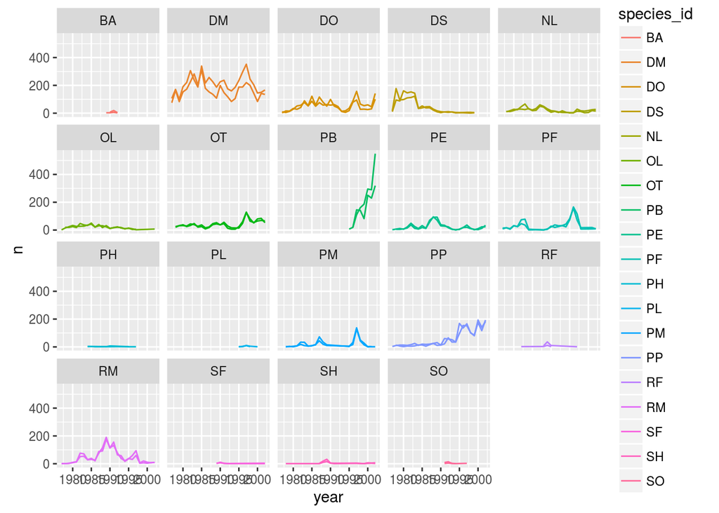

```r
ggplot(data = yearly_sex_counts, aes(x = year, y = n, color = species_id, group = sex)) +
  geom_line() + facet_wrap(~ species_id)
```

Usually plots with white background looks more readable in the publications. We can set the background to white using the function `theme_bw()`.

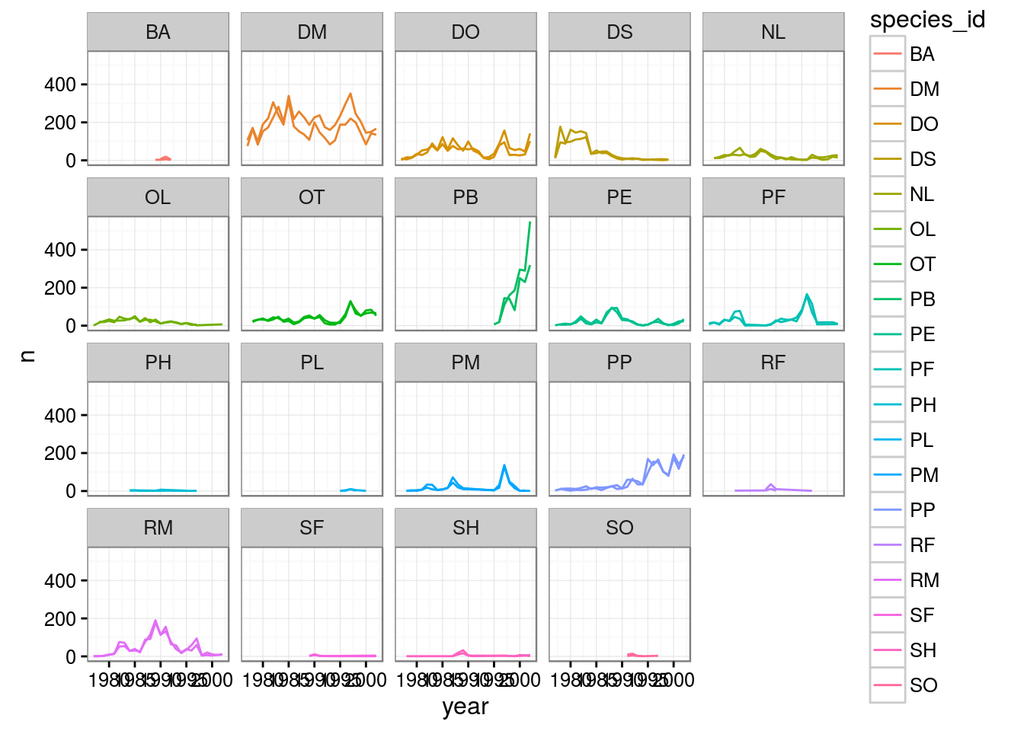

```r
ggplot(data = yearly_sex_counts, aes(x = year, y = n, color = species_id, group = sex)) +
  geom_line() + facet_wrap(~ species_id) + theme_bw()
```

> We can improve the plot by coloring by sex instead of species (species are already in separate plots, so we don’t need to distinguish them better)

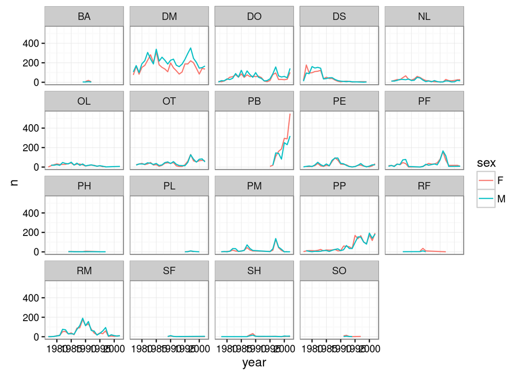

```r
ggplot(data = yearly_sex_counts, aes(x = year, y = n, color = sex, group = sex)) +
  geom_line() + facet_wrap(~ species_id) + theme_bw()
```

> - plot average weight of each species over the course of the years

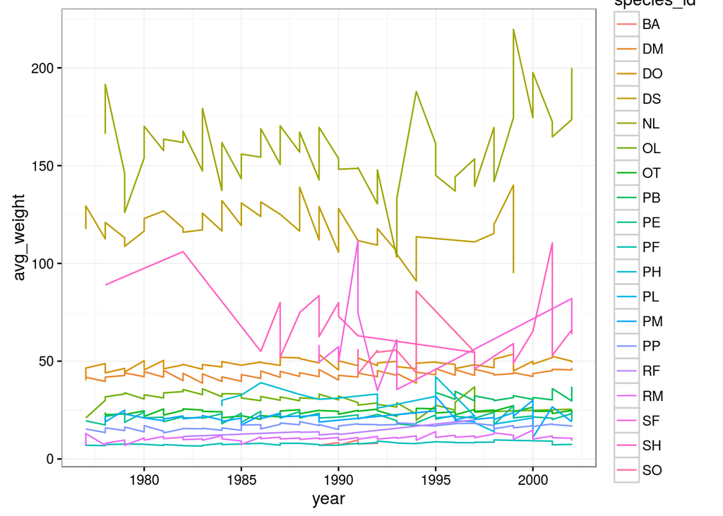

```r
yearly_weight <- surveys_complete %>%
                 group_by(year, species_id, sex) %>%
                 summarise(avg_weight = mean(weight, na.rm = TRUE))
ggplot(data = yearly_weight, aes(x=year, y=avg_weight, color = species_id, group = species_id)) +
  geom_line() + theme_bw()
```

> - why do you think we see those steps in the plot?
> - make separate plots per sex since weight of males and females can differ a lot

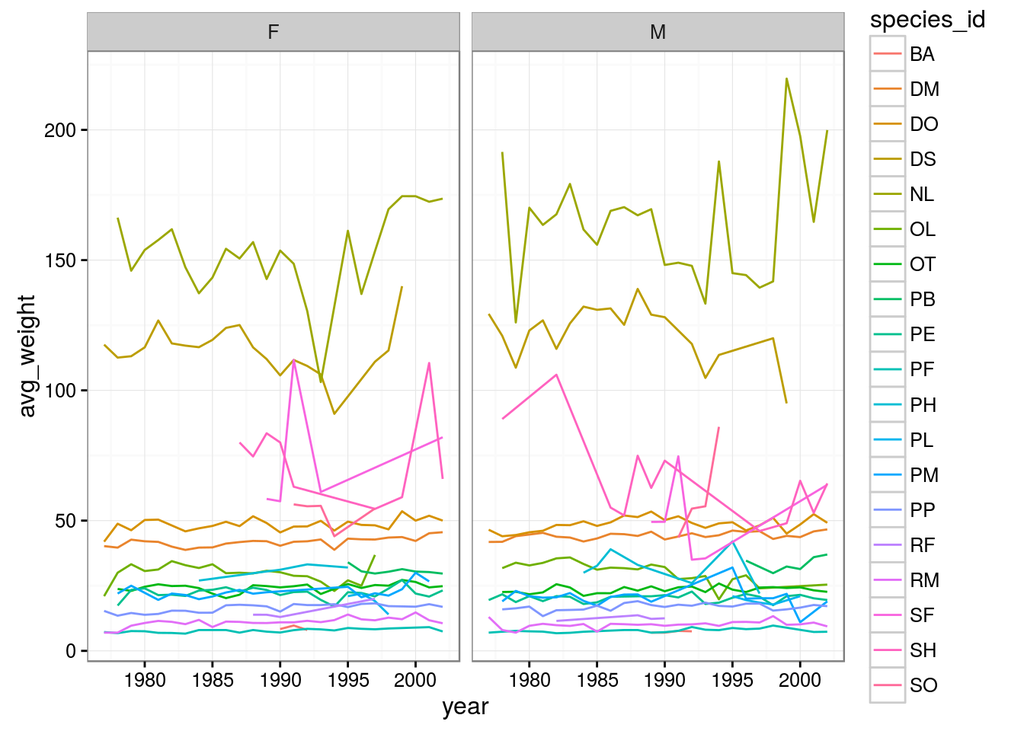

```r
ggplot(data = yearly_weight, aes(x=year, y=avg_weight, color = species_id, group = species_id)) +
  geom_line() + facet_wrap(~ sex) + theme_bw()
```

So far our result looks quite good, but it is yet far from being publishable. What are other ways one can improve it? Take a look at the ggplot2 cheat sheet (https://www.rstudio.com/wp-content/uploads/2015/08/ggplot2-cheatsheet.pdf), and write down at least three more ideas (can leave them as comments to Etherpad).

Now, let’s change names of axes to something more informative than ‘year’ and ‘n’ and add title to this figure:

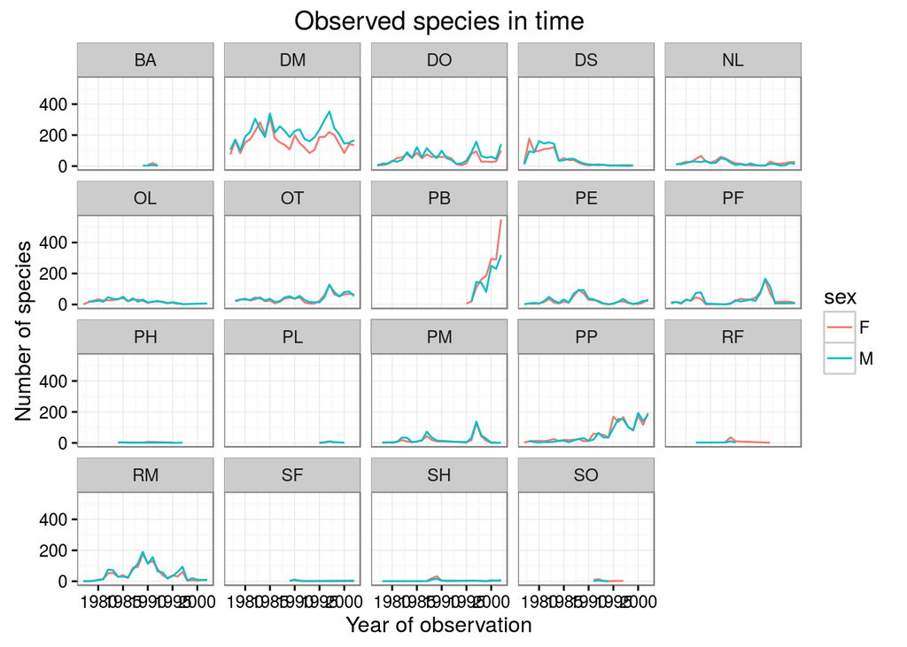

```r
ggplot(data = yearly_sex_counts, aes(x = year, y = n, color = sex, group = sex)) +
  geom_line() +
  facet_wrap(~ species_id) +
  labs(title = 'Observed species in time',
       x = 'Year of observation',
       y = 'Number of species') + theme_bw()
```

Now, thanks to our efforts, axes have much more informative names, yet quite small so it could be hard to read them. Let’s change their size (and font just in sake of fun):

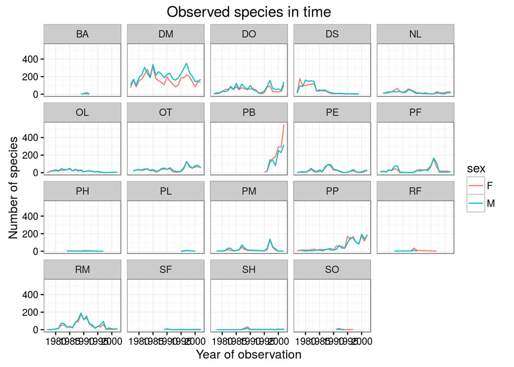

```r
ggplot(data = yearly_sex_counts, aes(x = year, y = n, color = sex, group = sex)) +
  geom_line() +
  facet_wrap(~ species_id) +
  labs(title = 'Observed species in time',
       x = 'Year of observation',
       y = 'Number of species') +
  theme(text=element_text(size=16, family="Arial")) + theme_bw()
```

After our manipulations we notice that the values on the x-axis are still not properly readable. Let’s change the orientation of the labels and adjust them vertically and horizontally so they don’t overlap. You can use a 90 degree angle, or experiment to find the appropriate angle for diagonally oriented labels.

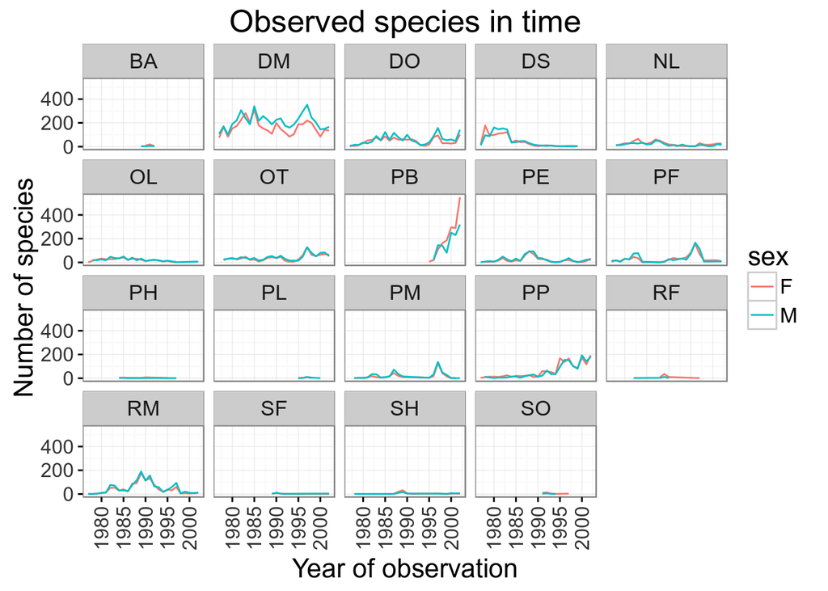

```r
ggplot(data = yearly_sex_counts, aes(x = year, y = n, color = sex, group = sex)) +
    geom_line() +
    facet_wrap(~ species_id) +
    theme_bw() +
    theme(axis.text.x = element_text(colour="grey20", size=12, angle=90, hjust=.5, vjust=.5),
          axis.text.y = element_text(colour="grey20", size=12),
          text=element_text(size=16, family="Arial")) +
    labs(title = 'Observed species in time',
         x = 'Year of observation',
         y = 'Number of species')
```

Now, labels became bigger and readable, but there are still few things that one could be improved. Please, take another five minutes and try to add another one or two things, to make it look even more beautiful. Use ggplot2 cheat sheet, which we linked earlier for inspiration.

Here are some ideas:

- See if you can change thickness of the lines.
- Can you find a way to change the name of the legend? What about its labels?
- Use different color palette to improve the look (http://www.cookbook-r.com/Graphs/Colors_(ggplot2)/)

When you created your perfect plot. You can save it to the file in your favourite format. You can easily change the size by specifying the width and height of your plot.

```r
ggsave("observed_species_in_time.png", width=15, height=10)
```

Enjoy plotting with ggplot2!